# Tugas Pertemuan 4

Anindya Dinar M

2026-09-15

# Proses MA (2)

## Bangkitkan data MA(2)

```r
#secara manual
set.seed(123)

n <- 300
e <- rnorm(n)

Y_MA2 <- numeric(n)

Y_MA2[1] <- e[1]
Y_MA2[2] <- e[2] + 0.4 * e[1]

for (t in 3:n) {
  Y_MA2[t] <- e[t] +
    0.4 * e[t-1] +
    0.6 * e[t-2]
}

MA2_manual <- ts(Y_MA2)

head(MA2_manual)
```

```
## Time Series:
## Start = 1
## End = 6
## Frequency = 1
## [1] -0.5604756 -0.4543677  1.1303519  0.5558852  1.0927161  1.8090851
```

```r
# dengan arima.sim()
set.seed(123)

MA2_sim <- arima.sim(
  n = 300,
  model = list(ma = c(0.4, 0.6))
)

head(MA2_sim)
```

```
## Time Series:
## Start = 1
## End = 6
## Frequency = 1
## [1]  1.13035193  0.55588522  1.09271608  1.80908512  1.22451484 -0.05165576
```

## Plot Time Series, ACF, PACF, EACF

```
## AR/MA
##   0 1 2 3 4 5 6 7 8 9 10 11 12 13
## 0 x x o x o o o o o o o  o  o  o
## 1 x x x x o o o o o o o  o  o  o
## 2 x x o x o o o o o o o  o  o  o
## 3 x x o o x o o o o o o  o  o  o
## 4 x x x x x o o o o o o  o  o  o
## 5 o x x x x o o o o o o  o  o  o
## 6 x o x x o o o o o o o  o  o  o
## 7 x x o x x o o o o o o  o  o  o
```

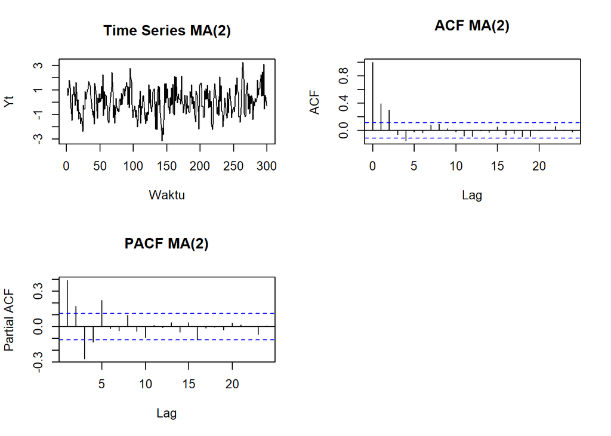

```r
par(mfrow = c(2,2))

plot(
  MA2_sim,
  main = "Time Series MA(2)",
  ylab = "Yt",
  xlab = "Waktu"
)

acf(
  MA2_sim,
  main = "ACF MA(2)"
)

pacf(
  MA2_sim,
  main = "PACF MA(2)"
)

library(TSA)
eacf(
  MA2_sim
)
```

Berdasarkan plot time series, data MA(2) berfluktuasi di sekitar nilai rata-rata dan tidak menunjukkan adanya tren. Pada ACF, korelasi akan terlihat signifikan sampai lag ke-2 dan kemudian terputus, sedangkan PACF cenderung menurun secara bertahap. Pola tersebut sesuai dengan karakteristik proses MA(2). Data dapat dianggap stasioner karena tidak menunjukkan pola tren atau perubahan varians yang sistematis.

## Scatter plot MA(2)

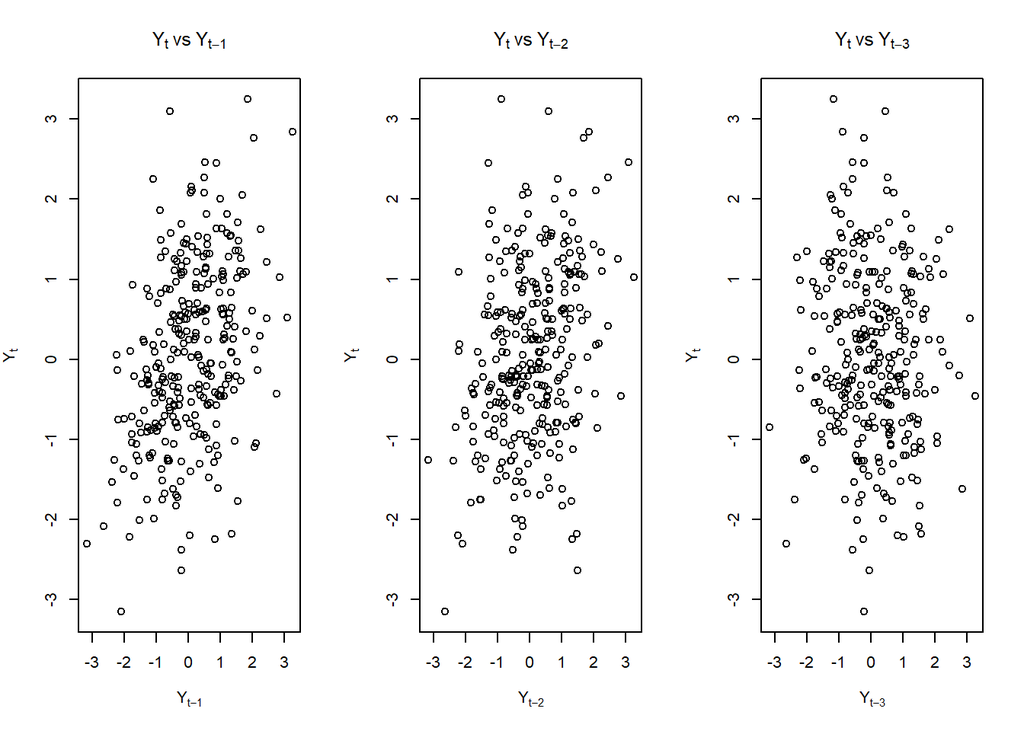

```r
par(mfrow = c(1,3))

plot(
  Y_MA2[-1],
  Y_MA2[-length(Y_MA2)],
  main = expression(Y[t] ~ "vs" ~ Y[t-1]),
  xlab = expression(Y[t-1]),
  ylab = expression(Y[t])
)

plot(
  Y_MA2[-c(1,2)],
  Y_MA2[-c(299,300)],
  main = expression(Y[t] ~ "vs" ~ Y[t-2]),
  xlab = expression(Y[t-2]),
  ylab = expression(Y[t])
)

plot(
  Y_MA2[-c(1,2,3)],
  Y_MA2[-c(298,299,300)],
  main = expression(Y[t] ~ "vs" ~ Y[t-3]),
  xlab = expression(Y[t-3]),
  ylab = expression(Y[t])
)
```

Scatterplot menunjukkan hubungan antara $Y_t$ dengan nilai masa lalunya. Pada proses MA(2), hubungan dengan lag 1 dan lag 2 masih dapat terlihat, sedangkan hubungan dengan lag 3 cenderung lebih lemah karena secara teoritis autokorelasi MA(2) terputus setelah lag ke-2.

## Autokorelasi MA(2)

```r
#empiris dari data
acf(MA2_sim, lag.max = 3, plot = FALSE)$acf
```

```
## , , 1
##
##            [,1]
## [1,]  0.3929133
## [2,]  0.3014933
## [3,] -0.0587174
```

```r
#teoritis
theta1 <- 0.4
theta2 <- 0.6

denom <- 1 + theta1^2 + theta2^2

rho1_MA2 <- (theta1 + theta1 * theta2) / denom
rho2_MA2 <- theta2 / denom
rho3_MA2 <- 0

rho_MA2 <- c(1, rho1_MA2, rho2_MA2, rho3_MA2)

rho_MA2
```

```
## [1] 1.0000000 0.4210526 0.3947368 0.0000000
```

Secara teoritis, autokorelasi MA(2) bernilai sekitar 0,4211 pada lag 1 dan 0,3947 pada lag 2, kemudian menjadi 0 pada lag 3. Hal ini menunjukkan bahwa proses MA(2) hanya memiliki ketergantungan sampai lag ke-2.

# Proses AR(2)

## Bangkitkan data AR(2)

```r
#dengan manual
set.seed(123)

n <- 300
e <- rnorm(n)

Y_AR2 <- numeric(n)

Y_AR2[1] <- e[1]
Y_AR2[2] <- 0.5 * Y_AR2[1] + e[2]

for (t in 3:n) {
  Y_AR2[t] <- 0.5 * Y_AR2[t-1] +
    0.2 * Y_AR2[t-2] +
    e[t]
}

AR2_manual <- ts(Y_AR2)

head(AR2_manual)
```

```
## Time Series:
## Start = 1
## End = 6
## Frequency = 1
## [1] -0.5604756 -0.5104153  1.1914055  0.5641281  0.6496329  2.1527070
```

```r
# dengan arima.sim()
set.seed(123)

AR2_sim <- arima.sim(
  n = 300,
  model = list(ar = c(0.5, 0.2))
)

head(AR2_sim)
```

```
## Time Series:
## Start = 1
## End = 6
## Frequency = 1
## [1] -2.9518714 -1.0047928 -0.9393975 -1.8087943  0.1615383  0.1454745
```

## Plot Time Series, ACF, PACF, EACF

```
## AR/MA
##   0 1 2 3 4 5 6 7 8 9 10 11 12 13
## 0 x x x o o o o o o o o  o  o  o
## 1 x o o x o o o o o o o  o  o  o
## 2 o o o o o o o o o o o  o  o  o
## 3 o x o o o o o o o o o  o  o  o
## 4 x x o o o x o o o o o  o  o  o
## 5 x x o x o o o o o o o  o  o  o
## 6 x x o x x o o o o o o  o  o  o
## 7 x x x x x o o o o o o  o  o  o
```

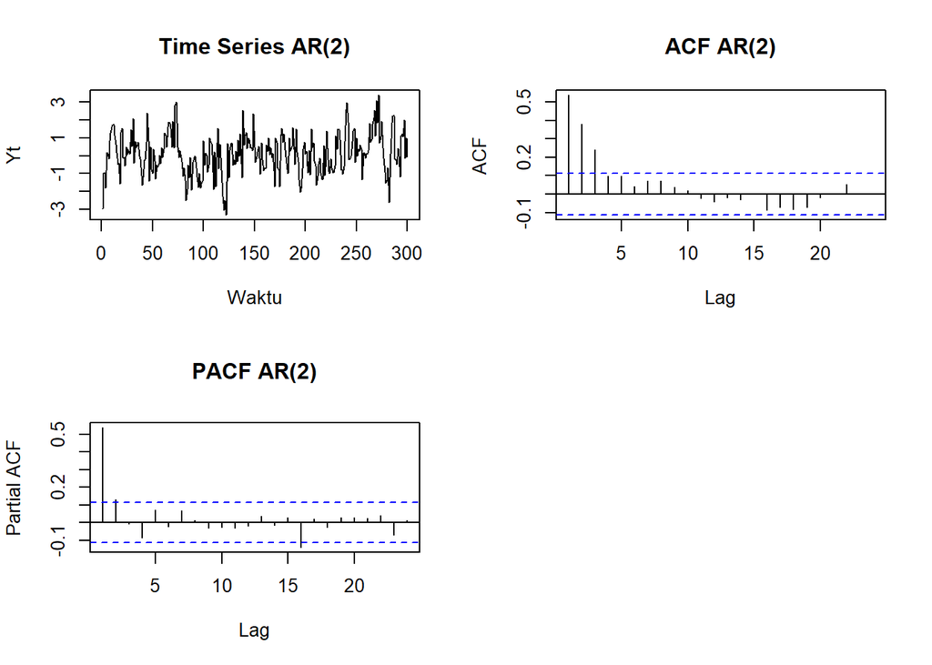

```r
par(mfrow = c(2,2))

plot(
  AR2_sim,
  main = "Time Series AR(2)",
  ylab = "Yt",
  xlab = "Waktu"
)

acf(
  AR2_sim,
  main = "ACF AR(2)"
)

pacf(
  AR2_sim,
  main = "PACF AR(2)"
)

library(TSA)

eacf(
  AR2_sim
)
```

Plot time series AR(2) menunjukkan data berfluktuasi di sekitar rata-rata tanpa pola tren yang jelas. Pada ACF, korelasi cenderung menurun secara bertahap, sedangkan PACF cenderung terputus setelah lag ke-2. Pola tersebut merupakan karakteristik proses AR(2). Data dapat dianggap stasioner karena nilai koefisien AR memenuhi kondisi stasioner.

## Scatterplot AR()

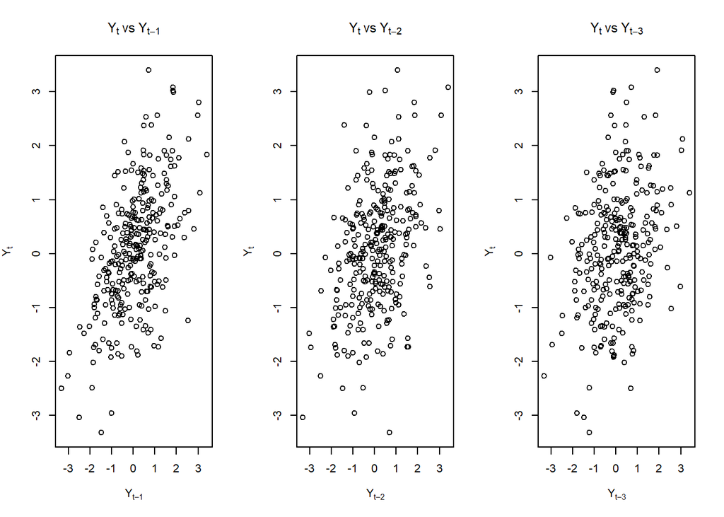

```r
par(mfrow = c(1,3))

plot(
  Y_AR2[-1],
  Y_AR2[-length(Y_AR2)],
  main = expression(Y[t] ~ "vs" ~ Y[t-1]),
  xlab = expression(Y[t-1]),
  ylab = expression(Y[t])
)

plot(
  Y_AR2[-c(1,2)],
  Y_AR2[-c(299,300)],
  main = expression(Y[t] ~ "vs" ~ Y[t-2]),
  xlab = expression(Y[t-2]),
  ylab = expression(Y[t])
)

plot(
  Y_AR2[-c(1,2,3)],
  Y_AR2[-c(298,299,300)],
  main = expression(Y[t] ~ "vs" ~ Y[t-3]),
  xlab = expression(Y[t-3]),
  ylab = expression(Y[t])
)
```

Scatterplot menunjukkan adanya hubungan antara $Y_t$ dengan nilai $Y$ pada periode sebelumnya. Karena proses AR(2) bergantung pada dua nilai sebelumnya, hubungan dengan lag 1 dan lag 2 cenderung lebih terlihat dibandingkan lag 3.

## Autokorelasi AR()

```r
# empiris
acf(AR2_sim, lag.max = 3, plot = FALSE)$acf
```

```
## , , 1
##
##           [,1]
## [1,] 0.5383654
## [2,] 0.3811747
## [3,] 0.2424933
```

```r
# teoritis
phi1 <- 0.5
phi2 <- 0.2

rho1_AR2 <- phi1 / (1 - phi2)

rho2_AR2 <- phi1 * rho1_AR2 + phi2

rho3_AR2 <- phi1 * rho2_AR2 +
  phi2 * rho1_AR2

rho_AR2 <- c(
  1,
  rho1_AR2,
  rho2_AR2,
  rho3_AR2
)

rho_AR2
```

```
## [1] 1.00000 0.62500 0.51250 0.38125
```

Autokorelasi teoritis AR(2) menunjukkan nilai sekitar 0,625 pada lag 1, 0,5125 pada lag 2, dan 0,3813 pada lag 3. Berbeda dengan MA(2), autokorelasi AR(2) tidak langsung terputus setelah lag ke-2, tetapi menurun secara bertahap.

# Proses ARMA(2,2)

## Bangkitkan data ARMA(2,2)

```r
#manual
set.seed(123)

n <- 300
e <- rnorm(n)

Y_ARMA22 <- numeric(n)

Y_ARMA22[1] <- e[1]

Y_ARMA22[2] <-
  0.5 * Y_ARMA22[1] +
  e[2] +
  0.4 * e[1]

for (t in 3:n) {
  Y_ARMA22[t] <-
    0.5 * Y_ARMA22[t-1] +
    0.2 * Y_ARMA22[t-2] +
    e[t] +
    0.4 * e[t-1] +
    0.6 * e[t-2]
}

ARMA22_manual <- ts(Y_ARMA22)

head(ARMA22_manual)
```

```
## Time Series:
## Start = 1
## End = 6
## Frequency = 1
## [1] -0.5604756 -0.7346056  0.6509540  0.7344411  1.5901274  2.7510371
```

```r
# dengan arima.sim()
set.seed(123)

ARMA22_sim <- arima.sim(
  n = 300,
  model = list(
    ar = c(0.5, 0.2),
    ma = c(0.4, 0.6)
  )
)

head(ARMA22_sim)
```

```
## Time Series:
## Start = 1
## End = 6
## Frequency = 1
## [1] -3.11187150 -2.78699743 -1.12528900 -0.87493596 -0.03472262  0.84062710
```

## Plot Time Series, ACF, PACF, EACF

```
## AR/MA
##   0 1 2 3 4 5 6 7 8 9 10 11 12 13
## 0 x x x x x o o o o o o  o  o  o
## 1 o x o o o x o o o o o  o  o  o
## 2 o x o o o x o o o o o  o  o  o
## 3 x x o x o x o o o o o  o  o  o
## 4 x x o x o x o o o o o  o  o  o
## 5 x x o x x o o o o o o  o  o  o
## 6 x x o x x o o o o o o  o  o  o
## 7 x x x x x o o o o o o  o  o  o
```

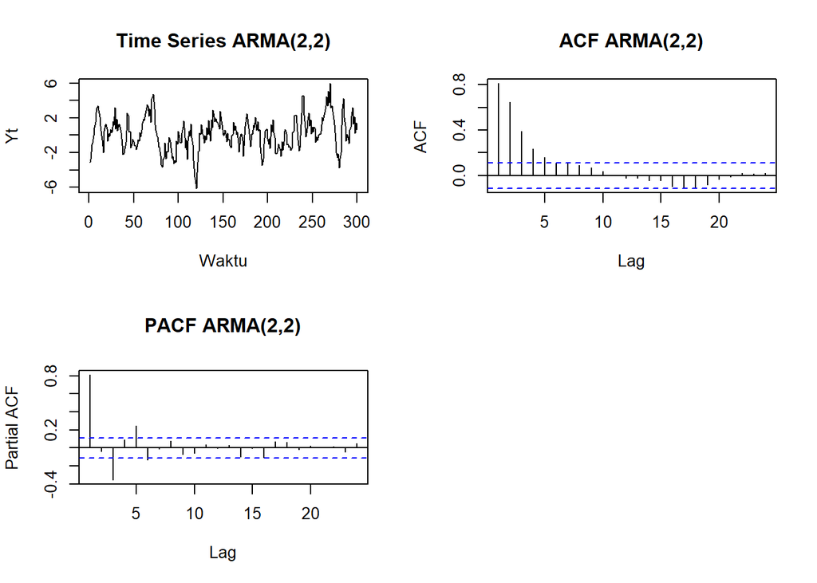

```r
par(mfrow = c(2,2))

plot(
  ARMA22_sim,
  main = "Time Series ARMA(2,2)",
  ylab = "Yt",
  xlab = "Waktu"
)

acf(
  ARMA22_sim,
  main = "ACF ARMA(2,2)"
)

pacf(
  ARMA22_sim,
  main = "PACF ARMA(2,2)"
)

library(TSA)

eacf(
  ARMA22_sim
)
```

Berdasarkan plot time series, data ARMA(2,2) berfluktuasi di sekitar rata-rata tanpa menunjukkan tren yang jelas. ACF dan PACF menunjukkan pola peluruhan yang merupakan karakteristik gabungan proses AR dan MA. Berdasarkan plot tersebut, data dapat dianggap stasioner karena tidak menunjukkan tren maupun perubahan varians yang sistematis.